# Maintenance cost reduction through predictive techniques

### Experimenting with non-linear methods

It seems that a simple logistic regression will not be the ideal model for this use case.  
I suspect tree based methods will perform better because the sensors indicate failure when they spike above a certain threshold, which trees can capture well.  
I will start with catboost because it trains quickly and requires less tuning than other gradient boosted methods.

```
<catboost.core.CatBoostClassifier at 0x298cf53e5e0>
```

```
Predicted positives: 485 Actual positives: 723
Confusion matrix
       0    1
0  33507   12
1    250  473
              precision    recall  f1-score   support

           0    0.99259   0.99964   0.99611     33519
           1    0.97526   0.65422   0.78311       723

    accuracy                        0.99235     34242
   macro avg    0.98393   0.82693   0.88961     34242
weighted avg    0.99223   0.99235   0.99161     34242
```

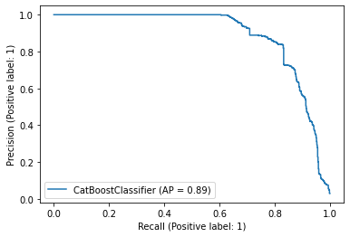

```python
cb = CatBoostClassifier(iterations=1000, learning_rate=0.03, loss_function='Logloss', reg_lambda=5,
                        verbose=False, random_seed=seed, has_time=True)
cb.fit(X, y)
preds = cb.predict(test[feature_set])

evaluate(cb, preds, y_test, X_test)
# Model: Catboost with all features and regularization
# Result: Massive improvement in all metrics
```

### Balancing false positives & false negatives

The catboost classifier is doing much better than logistic, but it's skewed to predict more false negatives, presumably due to the class imbalance.  
One technique for handling this is oversampling. I prefer to use SMOTE because it gives the model new synthetic samples to learn from.

```
(194286, 22)
```

```
<catboost.core.CatBoostClassifier at 0x298bb928910>
```

```
Predicted positives: 687 Actual positives: 723
Confusion matrix
       0    1
0  33346  173
1    209  514
              precision    recall  f1-score   support

           0    0.99377   0.99484   0.99430     33519
           1    0.74818   0.71093   0.72908       723

    accuracy                        0.98884     34242
   macro avg    0.87098   0.85288   0.86169     34242
weighted avg    0.98859   0.98884   0.98870     34242
```

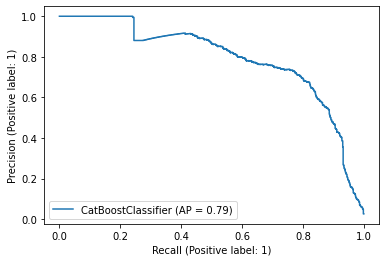

```python
smote = SMOTE(random_state=seed)
X_res, y_res = smote.fit_resample(X, y)
print(X_res.shape)

cb = CatBoostClassifier(iterations=1000, learning_rate=0.03, loss_function='Logloss', reg_lambda=5,
                        verbose=False, random_seed=seed, has_time=True)
cb.fit(X_res, y_res)
preds = cb.predict(test[feature_set])

evaluate(cb, preds, y_test, X_test)
# Model: Catboost with oversampling
# Result: Small hit to F1 score. More true positives, but at the expense of significantly more false positives.
```

### Threshold tuning

SMOTE helped to an extent, but the F1 score took a hit. I think we can have even better performance by adjusting the threshold for classifying a failure.  
I'll use precision & recall to identify a threshold which will give us an optimal F1 score and use that to generate predictions.

```python
cb = CatBoostClassifier(iterations=1000, learning_rate=0.03, loss_function='Logloss', reg_lambda=5,
                        verbose=False, random_seed=seed, has_time=True)
cb.fit(X, y)
preds = cb.predict_proba(test[feature_set])[:, 1]
precision, recall, thresholds = precision_recall_curve(y_test, preds)

# convert to f score
fscore = (2 * precision * recall) / (precision + recall)
# locate the index of the largest f score
ix = np.argmax(fscore)
print('Best Threshold=%f, F-Score=%.3f' % (thresholds[ix], fscore[ix]))
```

```
<catboost.core.CatBoostClassifier at 0x298df489f70>
```

```
Best Threshold=0.183521, F-Score=0.834
```

```python
preds = (preds > thresholds[ix]).astype(int)
evaluate(cb, preds, y_test, X_test, plot=False)
# Model: Catboost with threshold tuning
# Result: Marginally better F1 performance and much better balance of FP & FN
```

```
Predicted positives: 717 Actual positives: 723
Confusion matrix
       0    1
0  33402  117
1    123  600
              precision    recall  f1-score   support

           0    0.99633   0.99651   0.99642     33519
           1    0.83682   0.82988   0.83333       723

    accuracy                        0.99299     34242
   macro avg    0.91658   0.91319   0.91488     34242
weighted avg    0.99296   0.99299   0.99298     34242
```

### Analyze results

In order to see our classifier performance more tangibly, I will plot the failure probabilities for every device in the test set so we can see if they gradually increase 30 days before a failure like we'd expect.

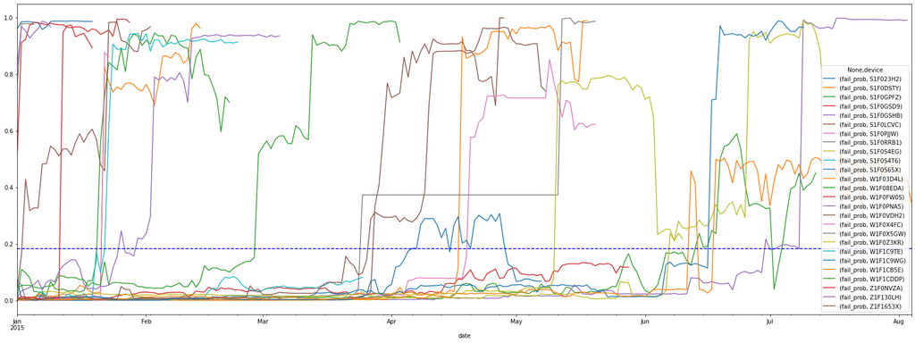

```python
probas = cb.predict_proba(test[feature_set])[:, 1]
test['fail_prob'] = probas
proba_plot_df = test.loc[test.device.isin(fails.index), ['device', 'date', 'fail_prob']].pivot_table(index='date', columns='device')
plot = proba_plot_df.plot(kind='line', figsize=(28, 10))
plot.axhline(y=thresholds[ix], color='b', linestyle='--')
```

### Can we do even better?

It's possible that bagging would do a better job than boosting in this case because each tree can learn the failure thresholds for each device type.  
Boosting would reduce errors of the residuals for a single tree and possibly create too complex of a decision boundary to perform well on a variety of devices.

```
RandomForestClassifier(n_jobs=-1, random_state=42)
```

```
Predicted positives: 701 Actual positives: 723
Confusion matrix
       0    1
0  33519    0
1     22  701
              precision    recall  f1-score   support

           0    0.99934   1.00000   0.99967     33519
           1    1.00000   0.96957   0.98455       723

    accuracy                        0.99936     34242
   macro avg    0.99967   0.98479   0.99211     34242
weighted avg    0.99936   0.99936   0.99935     34242
```

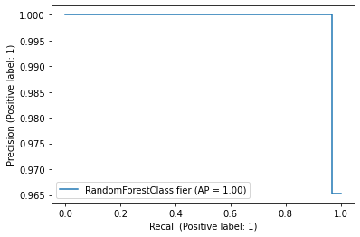

```python
rf = RandomForestClassifier(random_state=seed, n_jobs=-1)
rf.fit(X, y)
preds = rf.predict(test[feature_set])

evaluate(rf, preds, y_test, X_test)
# Model: out of box random forest
# Result: Nearly perfect performance, other than a few false negatives
```

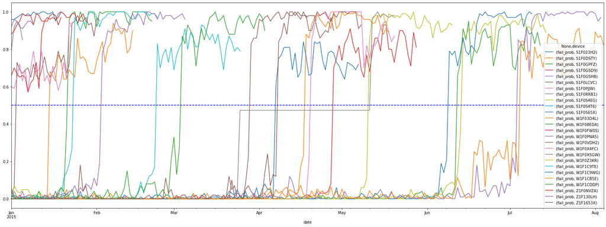

```python
probas = rf.predict_proba(test[feature_set])[:, 1]
test['fail_prob'] = probas
proba_plot_df = test.loc[test.device.isin(fails.index), ['device', 'date', 'fail_prob']].pivot_table(index='date', columns='device')
plot = proba_plot_df.plot(kind='line', figsize=(28, 10))
plot.axhline(y=0.5, color='b', linestyle='--')
```

### We've arrived at an ideal model

Random forest performs better than catboost without any tuning! This model has much clearer separation between high & low probabilities, so maintenance decision makers can have more confidence in the preditions they see.  
It seems that this model only suffers from a few false negatives, and all of them are for device W1F0X5GW where it flatlines in April just below the clssifier threshold.

As a final step, let's inspect the feature importances of the three models to see how much agreement there was between estimators and which features provided the most signal.

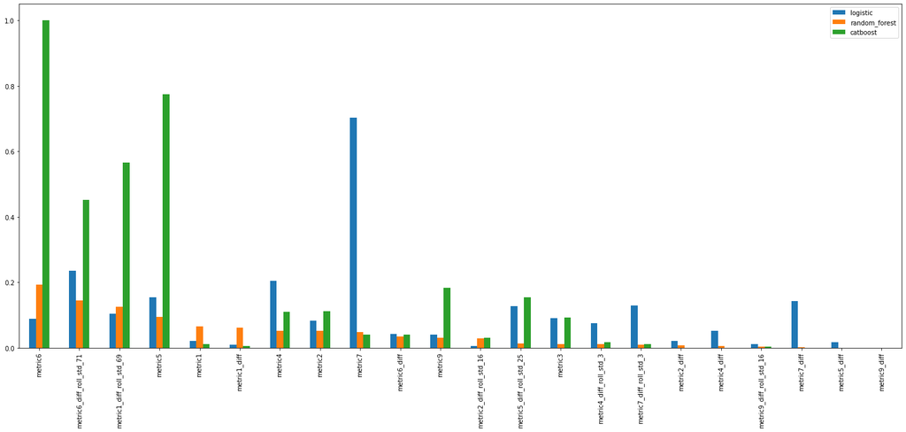

```python
# Compare feature importances
LR_coef = pd.DataFrame(search.best_estimator_.named_steps['LR'].coef_, columns=X.columns, index=['logistic']).T.abs()
catboost_featimp = pd.DataFrame(cb.feature_importances_, index=X.columns, columns=['catboost'])
catboost_featimp = catboost_featimp / catboost_featimp.catboost.max()
rf_featimp = pd.DataFrame(rf.feature_importances_, index=X.columns, columns=['random_forest'])
featimp = LR_coef.merge(rf_featimp, left_index=True, right_index=True).merge(catboost_featimp, left_index=True, right_index=True).sort_values('random_forest', ascending=False)
featimp.plot(kind='bar', figsize=(25, 10))
```

## Next steps

Given more time, I would want to explore deep learning techniques to better model the patterns which are predictive of failure. In this example, we did some very light feture engineering and were lucky enough to produce an accurate model, but I presume there is much more information packed in these metrics which could be better mined using sequence models such as LSTMs or transformers. Another approach would be to leverage a more exhaustive feature engineering framework like tsfresh or featuretools. I would also plan on using an interpretability framework like SHAP to better understand the features driving failure predictions at a local level.